# R assignment 1

Yuecheng Liu

April 2023

## Figures and Tables

### Automatic numbering and cross-referencing

Figures and tables can be automatically numbered by entering `label: fig-somename` or `label: tbl-somename` in the R-chunk header. You can create links in the text by referring to these labels using `@fig-somename` or `@tbl-somename`.

### How to make a figure caption

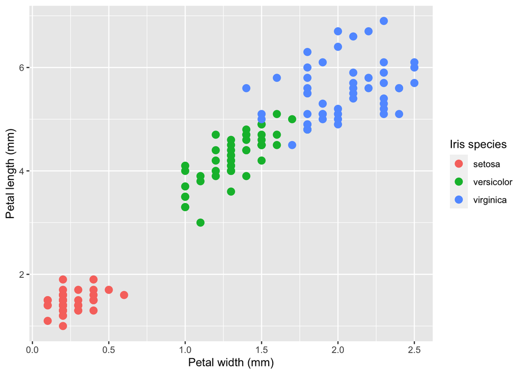

*This caption is in italics* .You can also use normal font.

```r
library(ggplot2)
ggplot(data=iris, mapping=aes(x=Petal.Width, y=Petal.Length, colour=Species)) +
  geom_point(size = 3) +
  labs(x="Petal width (mm)", y="Petal length (mm)", colour="Iris species")
```

You can put multiple sub-figures in one tableau, see examples on the [Quarto website](https://quarto.org/docs/authoring/figures.html).

#### Size of figures

Controlling the size of figures can be frustrating if you do not understand the parameters that determine size. There are four parameters that affect size: `fig-width`, `fig-height`, `out-width` and `out-height`. The first two parameters determine the size of the plotting device, whereas the third and fourth parameters determine the degree to which this plotting device is scaled in the document. I usually set the defaults by setting the global knitting parameters in the first R-chunk: `knitr::opts_chunk$set(fig.width=5, fig.height=5, out.width='50%', fig.align='center')`. In Quarto documents you can also put these global settings in the top yaml section under the `execute` sub-section, see the [Quarto documentation](https://quarto.org/docs/computations/execution-options.html). This leads to the following output:

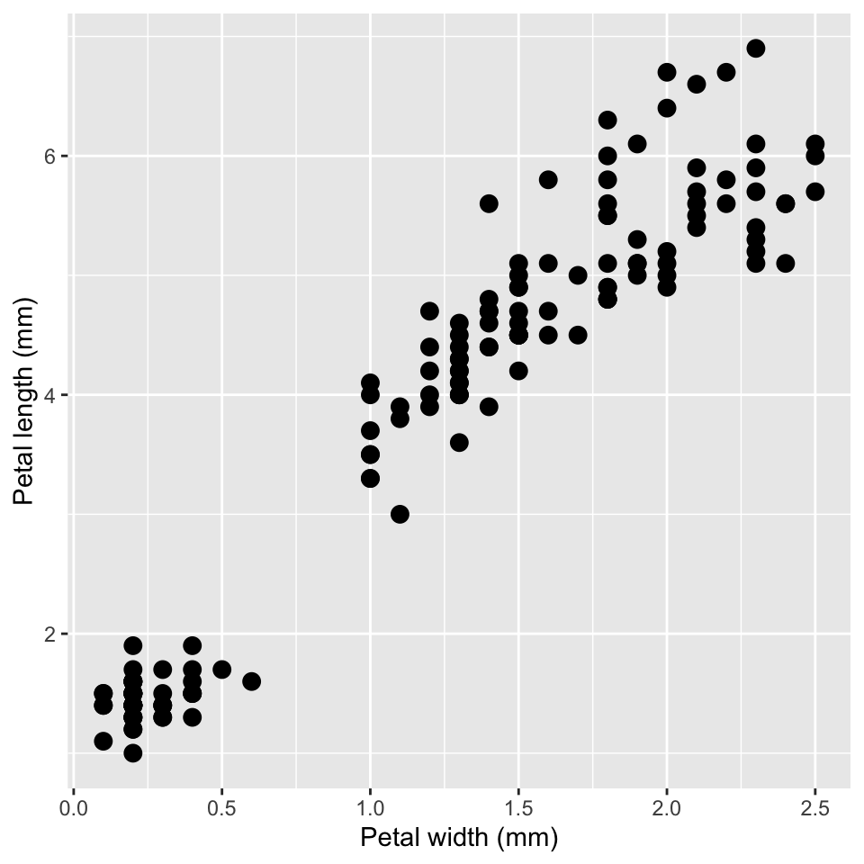

Decreasing to `fig-width: 3` and `fig-height: 3` decreases the size of the plotting device, but not the font size and size of other graphical elements in that device. The smaller device is subsequently enlarged to the same size as above because the `out-width` (and `out-height`) is the same:

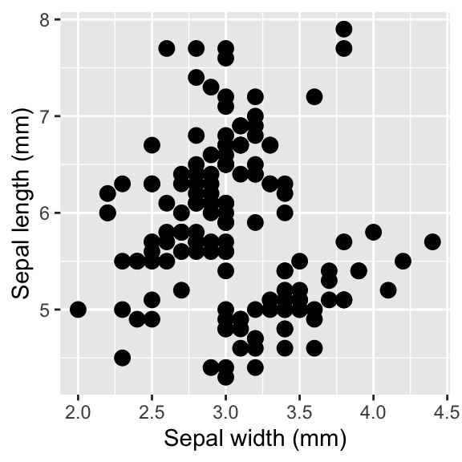

When making figures with other proportions you will usually want to adapt `fig-width` or `fig-height` as well as `out-width`, as in the case below where I plot two figures next to each other using the `patchwork` package and with chunk settings `fig-width: 10`, `fig-height: 5`, `out-width: 100%`:

[output not shown]

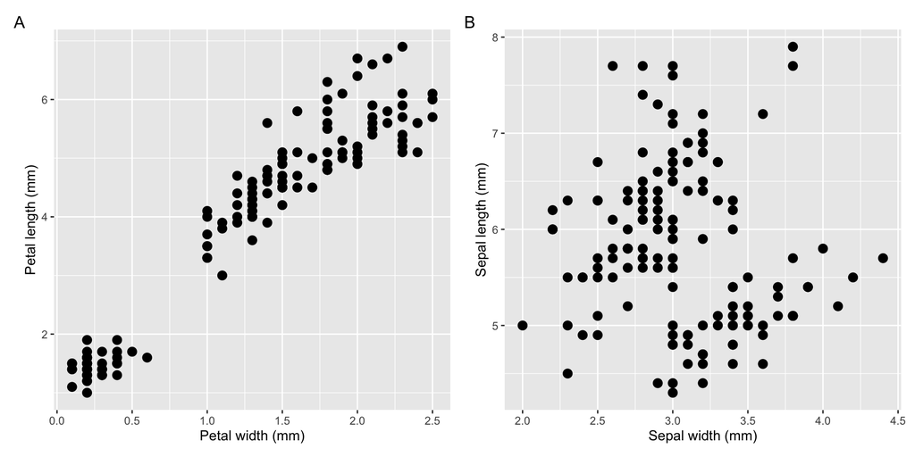

### Making tables with header caption

You can make tables using the `kable()` function from the `knitr` package, or more beautiful even, using the functions from the `kableExtra` package. **First install the latter package before continuing**.

Below, both methods are illustrated.

```r
knitr::kable(iris[1:5,],
             col.names=c("Sepal length", "Sepal width", "Petal length", "Petal width", "Species"),
             format="html")
```

| Sepal length | Sepal width | Petal length | Petal width | Species |
| --- | --- | --- | --- | --- |
| 5.1 | 3.5 | 1.4 | 0.2 | setosa |
| 4.9 | 3.0 | 1.4 | 0.2 | setosa |
| 4.7 | 3.2 | 1.3 | 0.2 | setosa |
| 4.6 | 3.1 | 1.5 | 0.2 | setosa |
| 5.0 | 3.6 | 1.4 | 0.2 | setosa |

```r
knitr::kable(iris[1:5,],
             col.names=c("Sepal length", "Sepal width", "Petal length", "Petal width", "Species"),
             format="html") |>
kableExtra::kable_classic(full_width=FALSE)
```

| Sepal length | Sepal width | Petal length | Petal width | Species |
| --- | --- | --- | --- | --- |
| 5.1 | 3.5 | 1.4 | 0.2 | setosa |
| 4.9 | 3.0 | 1.4 | 0.2 | setosa |
| 4.7 | 3.2 | 1.3 | 0.2 | setosa |
| 4.6 | 3.1 | 1.5 | 0.2 | setosa |
| 5.0 | 3.6 | 1.4 | 0.2 | setosa |

Generate the html output of this document by pushing the `Knit` button in Rstudio.

### Making bibliographic citations

How to include bibliographic citations is explained on the [Quarto website](https://quarto.org/docs/authoring/footnotes-and-citations.html). Briefly, you need a file with the cited literature, put the path of that file in the YAML header of the document under the section `bibliography` as demonstrated in the YAML header of this file. Subsequently you can cite in the text using the syntax explained on the quarto website.

You can also modify the citation style using a CSL file, however the default citation style is usually OK. The bibliography file can be provided in Bibtex or BibLatex, JSON, YAML or RIS, see the [pandoc](https://pandoc.org/MANUAL.html#citations) manual. With this template you will find a bibtex file `literature/A1.bib`.

In this assignment you will probably want to cite Venn-Watson and co-workers (2020).

Part 1. Checking the data 1.Load the data using the correct function from the readr or readxl packages.

```r
library(readxl)
sd01 = read_excel("/Users/liucheng/Desktop/Assignment_1/data/sd01.xlsx", skip=4)
sd02 = read_excel("/Users/liucheng/Desktop/Assignment_1/data/sd02.xlsx",skip=4 )
metadata = read.csv("/Users/liucheng/Desktop/Assignment_1/data/metadata.csv")


write.table(sd01, file = "sd01.txt", sep = "\t", row.names = FALSE)
write.table(sd02, file = "sd02.txt", sep = "\t", row.names = FALSE)
```

2.Study the data in the two excel files from the PNAS paper (Venn-Watson, Jensen, and Schork 2020) and describe their redundancies and how you would solve these (i.e. which tables would you make to resolve redundancies). What is in general the problem with redundancies?

Answer_2: Based on Based on the feature columns, it appears that the data includes information on the animals’ demographic information (AnimalID, sex, species, age, reason), laboratory measures (fasting, Labcode), and a range of hematological, biochemical, and metabolic parameters. Redundancy in a dataset means that there is either duplicate or overlapping information present in the data, which can lead to data inconsistencies and errors, as well as increased storage requirements and slower query processing times.

In this case, it can be observed that the values of the attribute “Reason, Fasting” are being repeated, and the “Labcode” is not required for data analysis. The first file includes information on animal ID, species, and age, and another table also includes information on animal ID and species but with different age values, so this is redundancy in the data.

To resolve these redundancies, I will make the age column in sd01 keep the same format as sd02.

3、Check the integrity of the data and if you conclude that there are errors then describe these and also how you want to correct them: what is the evidence for the correctness of your proposed modification? Display the evidence as well.

Answer_3:There are some of the columns have missing values.replace them with 0.

4、Now carry out your plan to remove redundancy from the data. Also correct errors according to your proposed modification. Display the top 6 lines of each of your new tables.

```r
library(readr)
library(dplyr)


sd01 = read_tsv("sd01.txt")
sd02 = read_tsv("sd02.txt")
sd01$Age = as.integer(sd01$Age)
#sd01
summary(sd01)
```

```
##     AnimalID          Sex              Species
##  Min.   :  1.00   Length:5889        Length:5889
##  1st Qu.: 20.00   Class :character   Class :character
##  Median : 39.00   Mode  :character   Mode  :character
##  Mean   : 48.56
##  3rd Qu.: 72.00
##  Max.   :145.00
##
##       Age           Reason          Fasting
##  Min.   : 0.00   Length:5889        Mode:logical
##  1st Qu.:13.00   Class :character   TRUE:5889
##  Median :21.00   Mode  :character
##  Mean   :21.88
##  3rd Qu.:31.00
##  Max.   :54.00
##
##     LabCode            WBC              RBC
##  Min.   : 4.000   Min.   : 0.800   Min.   : 1.47
##  1st Qu.: 6.000   1st Qu.: 6.600   1st Qu.: 3.07
##  Median : 6.000   Median : 7.700   Median : 3.29
##  Mean   : 7.395   Mean   : 8.171   Mean   : 3.28
##  3rd Qu.: 9.000   3rd Qu.: 9.300   3rd Qu.: 3.50
##  Max.   :13.000   Max.   :30.600   Max.   :14.20
##                                    NA's   :29
##       HGB            HCT             MCV
##  Min.   : 5.7   Min.   :15.90   Min.   : 11.8
##  1st Qu.:13.3   1st Qu.:39.60   1st Qu.:123.0
##  Median :14.2   Median :42.00   Median :128.0
##  Mean   :14.1   Mean   :41.96   Mean   :128.3
##  3rd Qu.:15.0   3rd Qu.:44.50   3rd Qu.:133.0
##  Max.   :20.7   Max.   :56.60   Max.   :156.9
##  NA's   :28     NA's   :26      NA's   :28
##       MCH              MCHC           RBCDist
##  Min.   :  4.40   Min.   :  3.50   Min.   :  1.30
##  1st Qu.: 41.70   1st Qu.: 33.00   1st Qu.: 13.80
##  Median : 43.40   Median : 33.90   Median : 14.90
##  Mean   : 43.17   Mean   : 33.62   Mean   : 15.66
##  3rd Qu.: 44.70   3rd Qu.: 34.70   3rd Qu.: 16.10
##  Max.   :439.00   Max.   :127.60   Max.   :138.00
##  NA's   :28       NA's   :26       NA's   :94
```

[output cut: 81 more lines]

```
##  Min.   :  0.00   Min.   :  11.0   Min.   :   0.0
##  1st Qu.: 50.00   1st Qu.: 139.0   1st Qu.:  99.0
##  Median : 66.00   Median : 184.0   Median : 125.0
##  Mean   : 81.74   Mean   : 203.6   Mean   : 138.3
##  3rd Qu.: 95.00   3rd Qu.: 249.0   3rd Qu.: 163.0
##  Max.   :788.00   Max.   :1023.0   Max.   :1878.0
##  NA's   :486      NA's   :74       NA's   :333
##      SED60               Mg             GFR
##  Min.   :  0.000   Min.   :0.000   Min.   :  0.0
##  1st Qu.:  3.000   1st Qu.:1.900   1st Qu.:174.1
##  Median :  7.000   Median :2.100   Median :221.0
##  Mean   :  9.793   Mean   :2.057   Mean   :217.5
##  3rd Qu.: 12.000   3rd Qu.:2.200   3rd Qu.:268.0
##  Max.   :130.000   Max.   :4.600   Max.   :862.1
##  NA's   :349       NA's   :3282    NA's   :367
```

```r
sd01_new = sd01%>%mutate_all(~ifelse(is.na(.),0,.))
summary(sd01_new)
```

```
##     AnimalID          Sex              Species
##  Min.   :  1.00   Length:5889        Length:5889
##  1st Qu.: 20.00   Class :character   Class :character
##  Median : 39.00   Mode  :character   Mode  :character
##  Mean   : 48.56
##  3rd Qu.: 72.00
##  Max.   :145.00
##       Age           Reason          Fasting
##  Min.   : 0.00   Length:5889        Mode:logical
##  1st Qu.:13.00   Class :character   TRUE:5889
##  Median :21.00   Mode  :character
##  Mean   :21.88
##  3rd Qu.:31.00
##  Max.   :54.00
##     LabCode            WBC              RBC
##  Min.   : 4.000   Min.   : 0.800   Min.   : 0.000
##  1st Qu.: 6.000   1st Qu.: 6.600   1st Qu.: 3.070
##  Median : 6.000   Median : 7.700   Median : 3.290
##  Mean   : 7.395   Mean   : 8.171   Mean   : 3.263
##  3rd Qu.: 9.000   3rd Qu.: 9.300   3rd Qu.: 3.500
##  Max.   :13.000   Max.   :30.600   Max.   :14.200
##       HGB             HCT             MCV
##  Min.   : 0.00   Min.   : 0.00   Min.   :  0.0
##  1st Qu.:13.30   1st Qu.:39.50   1st Qu.:122.9
##  Median :14.20   Median :42.00   Median :127.9
##  Mean   :14.03   Mean   :41.77   Mean   :127.7
##  3rd Qu.:15.00   3rd Qu.:44.50   3rd Qu.:133.0
##  Max.   :20.70   Max.   :56.60   Max.   :156.9
##       MCH              MCHC           RBCDist
##  Min.   :  0.00   Min.   :  0.00   Min.   :  0.00
##  1st Qu.: 41.70   1st Qu.: 33.00   1st Qu.: 13.80
##  Median : 43.40   Median : 33.90   Median : 14.90
##  Mean   : 42.97   Mean   : 33.47   Mean   : 15.41
##  3rd Qu.: 44.70   3rd Qu.: 34.70   3rd Qu.: 16.10
##  Max.   :439.00   Max.   :127.60   Max.   :138.00
##       NRBC           Platelets           MPV
##  Min.   : 0.0000   Min.   :  0.00   Min.   :  0.00
##  1st Qu.: 0.0000   1st Qu.: 72.00   1st Qu.: 11.30
##  Median : 0.0000   Median : 94.00   Median : 13.10
##  Mean   : 0.7074   Mean   : 94.14   Mean   : 11.75
```

[output cut: 64 more lines]

```
##  Max.   :2822   Max.   :8.6000   Max.   :582.0
##   Triglyceride      Iron             CPK
##  Min.   :  0   Min.   :   0.0   Min.   :   0.0
##  1st Qu.: 45   1st Qu.: 137.0   1st Qu.:  94.0
##  Median : 63   Median : 183.0   Median : 122.0
##  Mean   : 75   Mean   : 201.1   Mean   : 130.5
##  3rd Qu.: 91   3rd Qu.: 248.0   3rd Qu.: 160.0
##  Max.   :788   Max.   :1023.0   Max.   :1878.0
##      SED60               Mg              GFR
##  Min.   :  0.000   Min.   :0.0000   Min.   :  0.0
##  1st Qu.:  3.000   1st Qu.:0.0000   1st Qu.:174.1
##  Median :  6.000   Median :0.0000   Median :203.1
##  Mean   :  9.212   Mean   :0.9108   Mean   :203.9
##  3rd Qu.: 11.000   3rd Qu.:2.0000   3rd Qu.:243.0
##  Max.   :130.000   Max.   :4.6000   Max.   :862.1
```

```r
head(sd01_new)
```

```
## # A tibble: 6 × 51
##   AnimalID Sex   Species   Age Reason Fasting LabCode   WBC
##      <dbl> <chr> <chr>   <int> <chr>  <lgl>     <dbl> <dbl>
## 1        1 F     TT         26 R      TRUE          6   8.4
## 2        1 F     TT         26 R      TRUE          6  10.7
## 3        1 F     TT         26 R      TRUE          6   7.9
## 4        1 F     TT         25 R      TRUE          6   6.5
## 5        1 F     TT         25 R      TRUE          6   6.6
## 6        1 F     TT         25 R      TRUE          6   7.2
## # ℹ 43 more variables: RBC <dbl>, HGB <dbl>, HCT <dbl>,
## #   MCV <dbl>, MCH <dbl>, MCHC <dbl>, RBCDist <dbl>,
## #   NRBC <dbl>, Platelets <dbl>, MPV <dbl>, SEGS <dbl>,
## #   ACNeutrophils <dbl>, Lymphs <dbl>,
## #   ACLymphocytes <dbl>, Monocytes <dbl>,
## #   ACMonocytes <dbl>, EOS <dbl>, ACEosinophils <dbl>,
## #   Glucose <dbl>, BUN <dbl>, Creatinine <dbl>, …
```

5、Calculate the minimal age, maximal age and number of years (period) over which each of the Mid age animals (the ones from table sd02.xlsx) were followed. Also give a summary of these characteristics using the summary() function. You don’t have to make a proper table of the output of the summary() function.

```r
sd02_new = sd02%>%mutate_all(~ifelse(is.na(.),0,.))
min_age = min(sd02_new$Age)
max_age = max(sd02_new$Age)
min_age
```

```
## [1] 10
```